# Homework1

Sümeyra Özuğur

### 1)Import “heros_information” dataset from https://www.kaggle.com/claudiodavi/superhero-set

```r
#import data
mydata = read.csv("C:/Users/asus/Desktop/4.Sınıf/DataScience/sumeyra_ozugur_HW1/heroes_information.csv")
head(mydata)
```

```
##   X          name Gender Eye.color              Race Hair.color Height
## 1 0        A-Bomb   Male    yellow             Human    No Hair    203
## 2 1    Abe Sapien   Male      blue     Icthyo Sapien    No Hair    191
## 3 2      Abin Sur   Male      blue           Ungaran    No Hair    185
## 4 3   Abomination   Male     green Human / Radiation    No Hair    203
## 5 4       Abraxas   Male      blue     Cosmic Entity      Black    -99
## 6 5 Absorbing Man   Male      blue             Human    No Hair    193
##           Publisher Skin.color Alignment Weight
## 1     Marvel Comics          -      good    441
## 2 Dark Horse Comics       blue      good     65
## 3         DC Comics        red      good     90
## 4     Marvel Comics          -       bad    441
## 5     Marvel Comics          -       bad    -99
## 6     Marvel Comics          -       bad    122
```

### 2)How many male characters that have blue eyes are there?

```r
library(dplyr)
blue_eyes_male <- mydata %>%
     filter(Gender == "Male", Eye.color == "blue") %>%
     select(Gender,Eye.color)
count(blue_eyes_male)
```

```
##     n
## 1 143
```

```r
#for (number in blue_eyes_male){
  #print(number)
 # length(number)
#}
```

### 3) Remove bad alignment and answer Q2 again.

```r
    remove_bad_alignment <- mydata %>%
    filter(Alignment != "bad" & Eye.color=="blue" & Gender=="Male")

count(remove_bad_alignment)
```

```
##     n
## 1 108
```

### 4)What is the most common race and skin color? Create a summary table

```r
most_common_race <- mydata %>%
  group_by(Race) %>%
  filter(Race != "-") %>%
  summarise('Racee'=n())
arrange(most_common_race,desc(Racee))
```

```
## # A tibble: 61 x 2
##    Race              Racee
##    <chr>             <int>
##  1 Human               208
##  2 Mutant               63
##  3 God / Eternal        14
##  4 Cyborg               11
##  5 Human / Radiation    11
##  6 Android               9
##  7 Symbiote              9
##  8 Alien                 7
##  9 Kryptonian            7
## 10 Demon                 6
## # ... with 51 more rows
```

According to this output the most common Race is **Human** .

```r
most_common_skincolor <- mydata %>%
  group_by(Skin.color) %>%
   filter(Skin.color != "-") %>%
  summarise('SkinnColor'= n())
arrange(most_common_skincolor,desc(SkinnColor))
```

```
## # A tibble: 16 x 2
##    Skin.color     SkinnColor
##    <chr>               <int>
##  1 green                  21
##  2 blue                    9
##  3 red                     9
##  4 white                   7
##  5 grey                    5
##  6 silver                  5
##  7 gold                    3
##  8 purple                  3
##  9 pink                    2
## 10 yellow                  2
## 11 black                   1
## 12 blue-white              1
## 13 gray                    1
## 14 orange                  1
## 15 orange / white          1
## 16 red / black             1
```

According to this output the most common Skin.color is **green**.

### 5)Find out the mean and standard deviation of height and weight. Find the tallest and shortest heroes.

```r
mean_and_sd <- mydata %>%
  #select(Height,Weight) %>%
  filter(Weight >0 & Height >0) %>%

  summarise("Mean Weight" =  mean(Weight,na.rm = TRUE),
            " Mean Height" =mean(Height, na.rm = TRUE),
            "Standart_Devition_Weight" =sd(Weight,na.rm = TRUE),
            "Standart_Devition_Height" =sd(Height,na.rm = TRUE)
           )



mean_and_sd
```

```
##   Mean Weight  Mean Height Standart_Devition_Weight Standart_Devition_Height
## 1    112.1796     187.1239                 104.4227                 58.99002
```

```r
tallest_hero <- mydata %>%
 group_by(Height,name) %>%
  select(Height,name)%>%
  summarise("Height" = min(Height, na.rm = TRUE))



tail(tallest_hero)
```

```
## # A tibble: 6 x 2
## # Groups:   Height [5]
##   Height name
##    <dbl> <chr>
## 1    305 Sasquatch
## 2    366 MODOK
## 3    366 Wolfsbane
## 4    701 Groot
## 5    876 Galactus
## 6    975 Fin Fang Foom
```

In this table show us the tallest hero is **Fing Fang Foom**

```r
shortest_hero <- mydata %>%
 group_by(Height,name) %>%
  select(Height,name)%>%
  filter(Height >0)%>%
  summarise("Height" = min(Height, na.rm = TRUE))
head(shortest_hero)
```

```
## # A tibble: 6 x 2
## # Groups:   Height [5]
##   Height name
##    <dbl> <chr>
## 1   15.2 Utgard-Loki
## 2   30.5 Bloodwraith
## 3   30.5 King Kong
## 4   61   Anti-Monitor
## 5   62.5 Giganta
## 6   64   Krypto
```

In this table show us the shortest hero is **Utgard-Loki**.

### 6)Create tibbles showing weight and height for good and bad Marvel heros. Compare their mean and standard

deviation weight and height.

```r
#weight and height for good Marvel
  good_marvel <- mydata %>%
  select(Weight,Height,Alignment) %>%
  filter(Alignment=="good")  %>%
  # as_tibble() turns an existing object
  as_tibble(mydata)
good_marvel
```

```
## # A tibble: 496 x 3
##    Weight Height Alignment
##     <dbl>  <dbl> <chr>
##  1    441    203 good
##  2     65    191 good
##  3     90    185 good
##  4    -99    -99 good
##  5     88    185 good
##  6     61    173 good
##  7     81    178 good
##  8    104    191 good
##  9     90    180 good
## 10    -99    -99 good
## # ... with 486 more rows
```

```r
#weight and height for bad Marvel
  bad_marvel <- mydata %>%
  select(Weight,Height,Alignment) %>%
  filter(Alignment=="bad")  %>%
  # as_tibble() turns an existing object
  as_tibble(mydata)

bad_marvel
```

```
## # A tibble: 207 x 3
##    Weight Height Alignment
##     <dbl>  <dbl> <chr>
##  1    441    203 bad
##  2    -99    -99 bad
##  3    122    193 bad
##  4    108    188 bad
##  5     90    193 bad
##  6    -99    -99 bad
##  7    169    244 bad
##  8    173    257 bad
##  9    101    188 bad
## 10    -99    -99 bad
## # ... with 197 more rows
```

```r
# Compare their standard


diff_marvels <- mydata %>%
  select(Weight,Height,Alignment) %>%
  summarise("sd_height_bad_marvels" = sd(Height[Alignment == "bad"],  na.rm = TRUE),
            "sd_height_good_marvels" = sd(Height[Alignment == "good"],  na.rm = TRUE),
            "dff_sd_height_result" = ( sd_height_good_marvels - sd_height_bad_marvels),
            "sd_weight_bad_marvels" = sd(Weight[Alignment == "bad"],  na.rm = TRUE),
            "sd_weight_good_marvels" = sd(Weight[Alignment == "good"],  na.rm = TRUE),
            "dff_sd_weight_result" = ( sd_weight_bad_marvels - sd_weight_good_marvels))
diff_marvels
```

```
##   sd_height_bad_marvels sd_height_good_marvels dff_sd_height_result
## 1              133.0755                138.245             5.169476
##   sd_weight_bad_marvels sd_weight_good_marvels dff_sd_weight_result
## 1              149.0169               112.6797             36.33713
```

```r
# Compare their mean

diff_marvels <- mydata %>%
  select(Weight,Height,Alignment) %>%
  summarise("mean_height_bad_marvels" = mean(Height[Alignment == "bad"],  na.rm = TRUE),
            "mean_height_good_marvels" = mean(Height[Alignment == "good"],  na.rm = TRUE),
            "dff_mean_height_result" = ( mean_height_good_marvels - mean_height_bad_marvels),
            "mean_weight_bad_marvels" = mean(Weight[Alignment == "bad"],  na.rm = TRUE),
            "mean_weight_good_marvels" = mean(Weight[Alignment == "good"],  na.rm = TRUE),
            "dff_mean_weight_result" = ( mean_weight_bad_marvels - mean_weight_good_marvels))

diff_marvels
```

```
##   mean_height_bad_marvels mean_height_good_marvels dff_mean_height_result
## 1                 105.542                 98.87762              -6.664408
##   mean_weight_bad_marvels mean_weight_good_marvels dff_mean_weight_result
## 1                 65.6165                 31.87677               33.73974
```

### 7) Import “super_hero_powers” dataset from https://www.kaggle.com/claudiodavi/superhero-setCombine powers and

information datasets. Give 10 point to each power that is TRUE. Compute the power of each superhero. Write a dplyr chain to plot power of female human heros and show differences for alignment.

```r
super_hero_power = read.csv("C:/Users/asus/Desktop/4.Sınıf/DataScience/sumeyra_ozugur_HW1/super_hero_powers.csv")
#super_hero_power

hero_stats <- inner_join(mydata,super_hero_power, c("name"= "hero_names"))
```

```r
#
super_hero_cal <- function(x) {

  super_power_list <- c()
  for(i in 1:660) {
    power = 0
    for (j in 12:178) {
      if(x[i, j] == "True") {
        power = power + 10
      }
      else{
        power= power
      }


    }
    super_power_list <- c(super_power_list, power)
  }

  #hero_stats$Power <- super_power_list
  return(super_power_list)
}
```

```r
hero_stats$power <- super_hero_cal(hero_stats)
```

```r
human_female <- hero_stats %>%
filter(Gender=="Female" & Race =="Human" & Alignment != "-" )
```

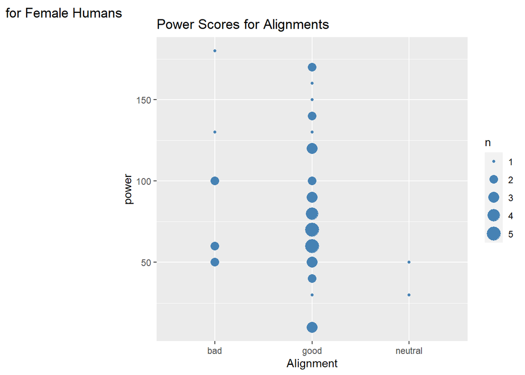

```r
#install.packages("ggplot2")
library(ggplot2)
ggplot(human_female) + geom_count(aes(x = Alignment, y = power), color = "steelblue") +
  labs(tag = "for Female Humans",
        title = "Power Scores for Alignments")
```

if Alignment is “good” ,there are more female. if Alignment is “neutral”, there is the least female. Alignment of the most powerful is bad.